# Data Visualization using ggplot2 & plotly

Geoms in base ggplot2:

```
##  [1] "geom_abline"     "geom_area"       "geom_bar"
##  [4] "geom_bin2d"      "geom_blank"      "geom_boxplot"
##  [7] "geom_col"        "geom_contour"    "geom_count"
## [10] "geom_crossbar"   "geom_curve"      "geom_density"
## [13] "geom_density_2d" "geom_density2d"  "geom_dotplot"
## [16] "geom_errorbar"   "geom_errorbarh"  "geom_freqpoly"
## [19] "geom_hex"        "geom_histogram"  "geom_hline"
## [22] "geom_jitter"     "geom_label"      "geom_line"
## [25] "geom_linerange"  "geom_map"        "geom_path"
## [28] "geom_point"      "geom_pointrange" "geom_polygon"
## [31] "geom_qq"         "geom_qq_line"    "geom_quantile"
## [34] "geom_raster"     "geom_rect"       "geom_ribbon"
## [37] "geom_rug"        "geom_segment"    "geom_sf"
## [40] "geom_sf_label"   "geom_sf_text"    "geom_smooth"
## [43] "geom_spoke"      "geom_step"       "geom_text"
## [46] "geom_tile"       "geom_violin"     "geom_vline"
```

You can add multiple layers of geoms into the same plot. In the example below, we are adding a semi-transparent path line on top of the points layer. Note that the path geom also uses the “data” and x-y definitions we defined in the `ggplot()` function.

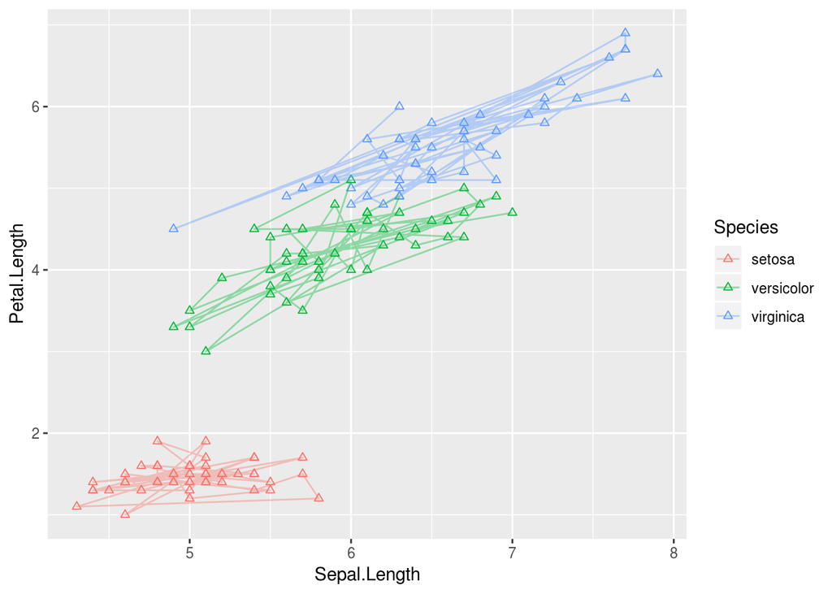

```r
ggplot(iris, aes(x = Sepal.Length, y = Petal.Length, color = Species)) +
  geom_point(shape = 2) +
  geom_path(alpha = 0.4)
```

You can also find hints on which geom to use by checking out the `ggplot2` cheatsheet. You can find one here:

[figure not shown]

https://github.com/rstudio/cheatsheets/blob/master/data-visualization-2.1.pdf

It is also critically important to understand where to put “variables”. Let’s take a look at example 1 again. There are 3 kinds of variables here:

- **data**: The first variable in `ggplot()` or inside `data =` in any `geoms`.
- **variable aesthetics**: Variables defined within `aes()`
- **constant aesthetics**: variables defined outside `aes()`

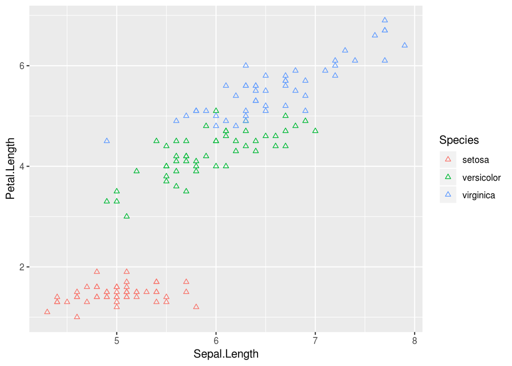

```r
ggplot(iris, aes(x = Sepal.Length, y = Petal.Length, color = Species)) +
  geom_point(shape = 2)
```

The `data` and `aes()` defined in `ggplot()` globally affects the entire “canvas”. You can also define them locally within each `geom`. This is especially helpful if you want to add a layer of data, which was not included in the orginal dataset.

```r
# The previous example can be rewritten as below.
ggplot() +
  geom_point(data = iris, aes(x = Sepal.Length, y = Petal.Length, color = Species),
             shape = 2)
```

## Scale

In previous examples, we have used the `aes()` function to assign data into several aesthetic aspects, such as the x & y axis. Common aesthetic variable include:

- x
- y
- color/colour
- fill
- alpha
- size
- linetype
- shape

The default settings in `ggplot` works in certain ways but we always want to be able to customize these settings. In fact, these aesthetic aspects can then be further customized using the family of `scale` function. Here we list out all scale functions in base ggplot2:

```
##  [1] "scale_alpha"               "scale_alpha_continuous"
##  [3] "scale_alpha_date"          "scale_alpha_datetime"
##  [5] "scale_alpha_discrete"      "scale_alpha_identity"
##  [7] "scale_alpha_manual"        "scale_alpha_ordinal"
##  [9] "scale_color_brewer"        "scale_color_continuous"
## [11] "scale_color_discrete"      "scale_color_distiller"
## [13] "scale_color_gradient"      "scale_color_gradient2"
## [15] "scale_color_gradientn"     "scale_color_grey"
## [17] "scale_color_hue"           "scale_color_identity"
## [19] "scale_color_manual"        "scale_color_viridis_c"
## [21] "scale_color_viridis_d"     "scale_colour_brewer"
## [23] "scale_colour_continuous"   "scale_colour_date"
## [25] "scale_colour_datetime"     "scale_colour_discrete"
## [27] "scale_colour_distiller"    "scale_colour_gradient"
## [29] "scale_colour_gradient2"    "scale_colour_gradientn"
```

[output cut: 32 more lines]

You can simply “add” these scale functions into your ggplot calls.

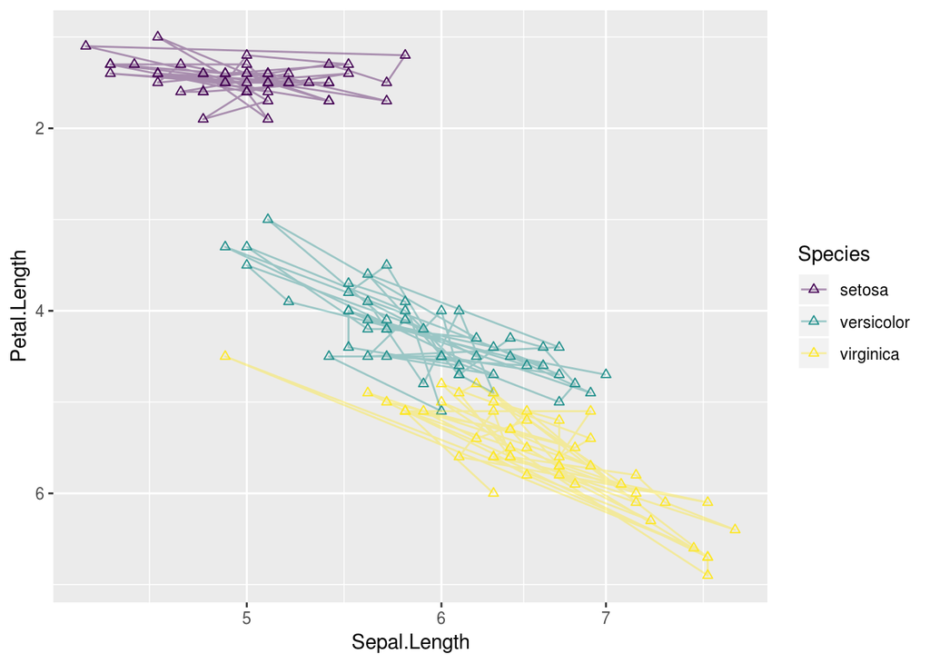

```r
ggplot(iris, aes(x = Sepal.Length, y = Petal.Length, color = Species)) +
  geom_point(shape = 2) +
  geom_path(alpha = 0.4) +
  scale_x_log10() + # log transformation for x axis
  scale_y_reverse() + # reverse y axis
  scale_color_viridis_d() # viridis color makes plots look scientific.
```

```r
                          # _d means discrete. _c means continuous.
```

## Coorinate

Although `scale` can modify axes, these modifications belong to the individual axis. If what you want to change is something beyond that, for example, the relationship/layout between the axes, you need to use the `coord_` coordinate function family.

For example, `coord_polar()` will squeeze the axes and transform the plot into a radar plot whereas `coord_fixed()` will force the two axes to use the same scale to show their 1:1 (or customized) relationship. What I find most useful is the `coord_flip()` function, which can flip the x-y axis. This is really helpful when you make a forest plot.

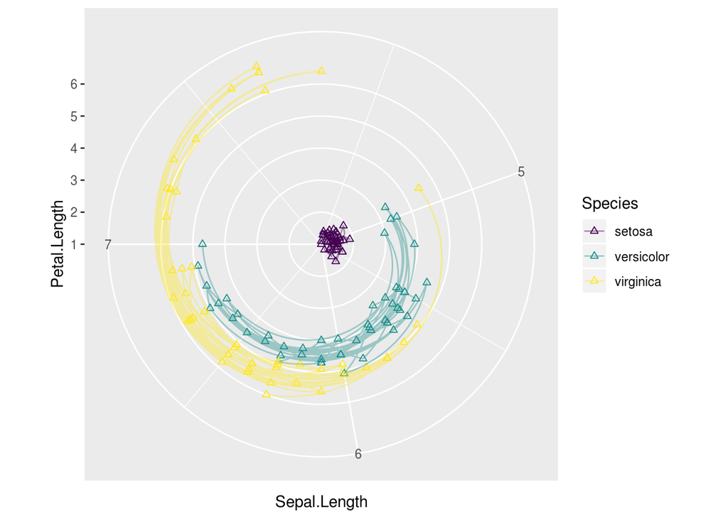

```r
ggplot(iris, aes(x = Sepal.Length, y = Petal.Length, color = Species)) +
  geom_point(shape = 2) +
  geom_path(alpha = 0.4) +
  scale_color_viridis_d() +
  coord_polar()
```

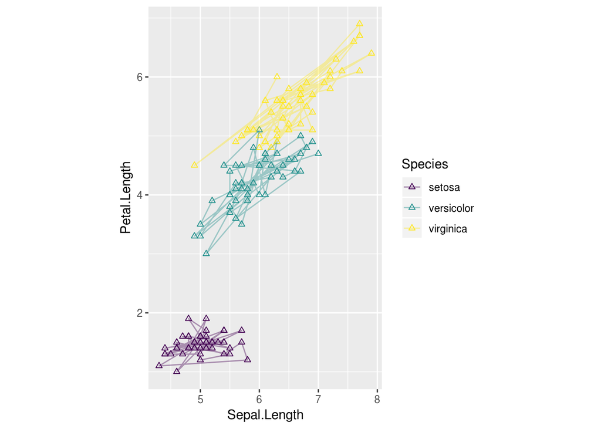

```r
ggplot(iris, aes(x = Sepal.Length, y = Petal.Length, color = Species)) +
  geom_point(shape = 2) +
  geom_path(alpha = 0.4) +
  scale_color_viridis_d() +
  coord_fixed()
```

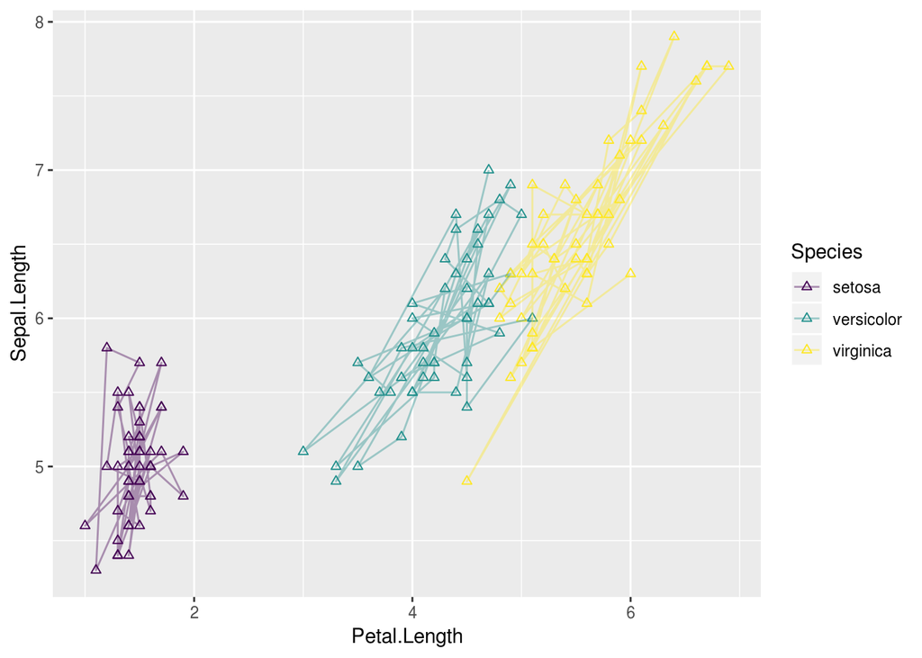

```r
ggplot(iris, aes(x = Sepal.Length, y = Petal.Length, color = Species)) +
  geom_point(shape = 2) +
  geom_path(alpha = 0.4) +
  scale_color_viridis_d() +
  coord_flip()
```

## Facets

Facets in ggplots refer to multiple subpanels of the “same” plot. It can be done through the `facet_grid()` (2D) or `face_wrap()` (1D) functions.

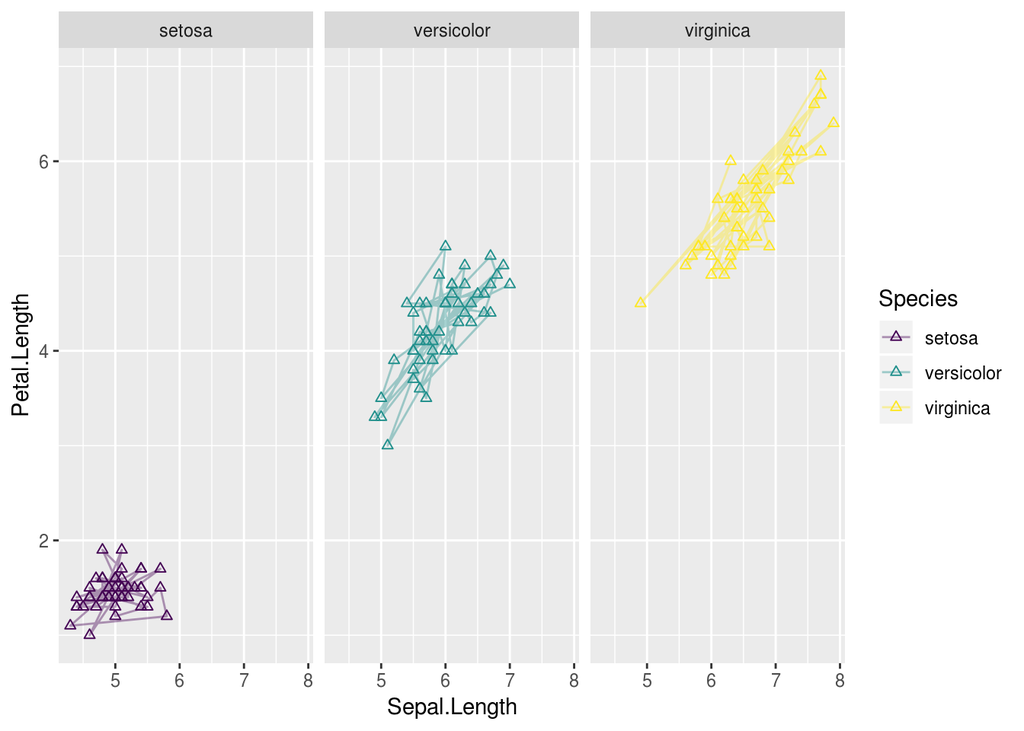

```r
ggplot(iris, aes(x = Sepal.Length, y = Petal.Length, color = Species)) +
  geom_point(shape = 2) +
  geom_path(alpha = 0.4) +
  scale_color_viridis_d() +
  facet_wrap(~Species)
```

## Theme

### `theme_` family

Theme in `ggplot` controls how the plot will look in general, including the color of the panel and the font of the axis. `ggplot2` comes with a few pre-defined themes. You can access them through the `theme_` prefix. For example, `theme_minimal` will remove the gray background and borders from the default of ggplot2.

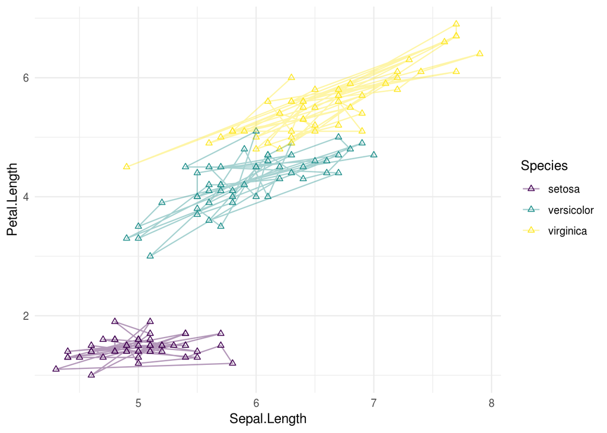

```r
ggplot(iris, aes(x = Sepal.Length, y = Petal.Length, color = Species)) +
  geom_point(shape = 2) +
  geom_path(alpha = 0.4) +
  scale_color_viridis_d() +
  theme_minimal()
```

Here at the Marcus Institute, we developed our own theme called `razor`.

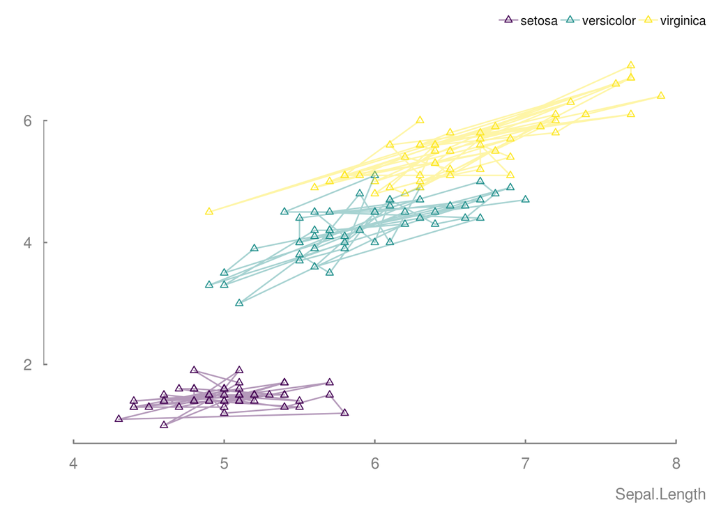

```r
library(ggrazor)

ggplot(iris, aes(x = Sepal.Length, y = Petal.Length, color = Species)) +
  geom_point(shape = 2) +
  geom_path(alpha = 0.4) +
  scale_color_viridis_d() +
  theme_razor() +
  # you can add additional stuff to make it look better.
  theme(axis.line = element_blank()) +
  ggthemes::geom_rangeframe(data = data.frame(x = c(4, 8), y = c(2, 6)),
                            aes(x, y), color = "#7F7F7F", show.legend = F)
```

### `theme()` function

If you want to customize the theme in detail, which we usually do, you need to use the theme function. Here is a reference page of what you can do but in most cases, you can find what you need via auto-complete in RStudio.

https://ggplot2.tidyverse.org/reference/ggtheme.html

## Position dodge/jitter

Most `geom`s come with a position argument. You can adjust the position of the points/bars a little so that they are not over lapping. However, dodge/jitter do not only help you get away with overlapping points, they can also help you make clustered plots.

```r
iris_sum <- iris %>%
  gather("key", "value", -Species) %>%
  group_by(Species, key) %>%
  summarise(mean = mean(value),
            sd = sd(value)) %>%
  mutate(low = mean - 1.96 * sd, high = mean + 1.96 * sd)
head(iris_sum)
```

```
## # A tibble: 6 x 6
## # Groups:   Species [2]
##   Species    key           mean    sd    low  high
##   <fct>      <chr>        <dbl> <dbl>  <dbl> <dbl>
## 1 setosa     Petal.Length 1.46  0.174 1.12   1.80
## 2 setosa     Petal.Width  0.246 0.105 0.0394 0.453
## 3 setosa     Sepal.Length 5.01  0.352 4.32   5.70
## 4 setosa     Sepal.Width  3.43  0.379 2.69   4.17
## 5 versicolor Petal.Length 4.26  0.470 3.34   5.18
## 6 versicolor Petal.Width  1.33  0.198 0.938  1.71
```

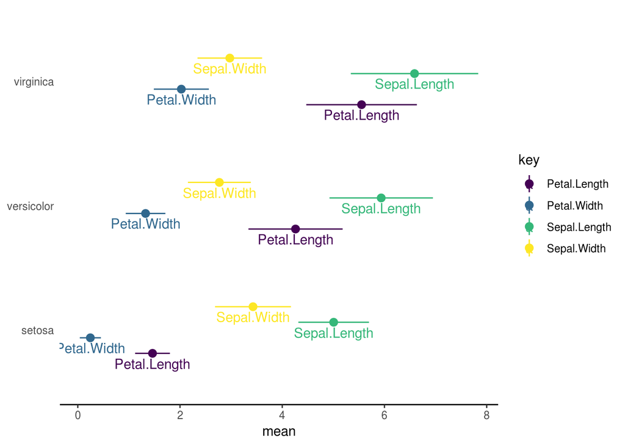

```r
ggplot(iris_sum, aes(x = Species, y = mean, ymin = low, ymax = high,
                     color = key)) +
  geom_pointrange(position = position_dodge(0.5)) +
  geom_text(aes(label = key),
            position = position_dodge(0.5), vjust = 1.5) +
  scale_color_viridis_d() +
  coord_flip() +
  theme(legend.position = "none") +
  theme_classic() +
  theme(
    axis.line.y = element_blank(),
    axis.ticks.y = element_blank()
  ) +
  labs(x = NULL)
```

## Multi-plot panel

There are a number of ways to combine multiple ggplots into one and `cowplot` is one of the bests. Note that this package will change the default theme of `ggplot` to the classic one due to the author’s preference.

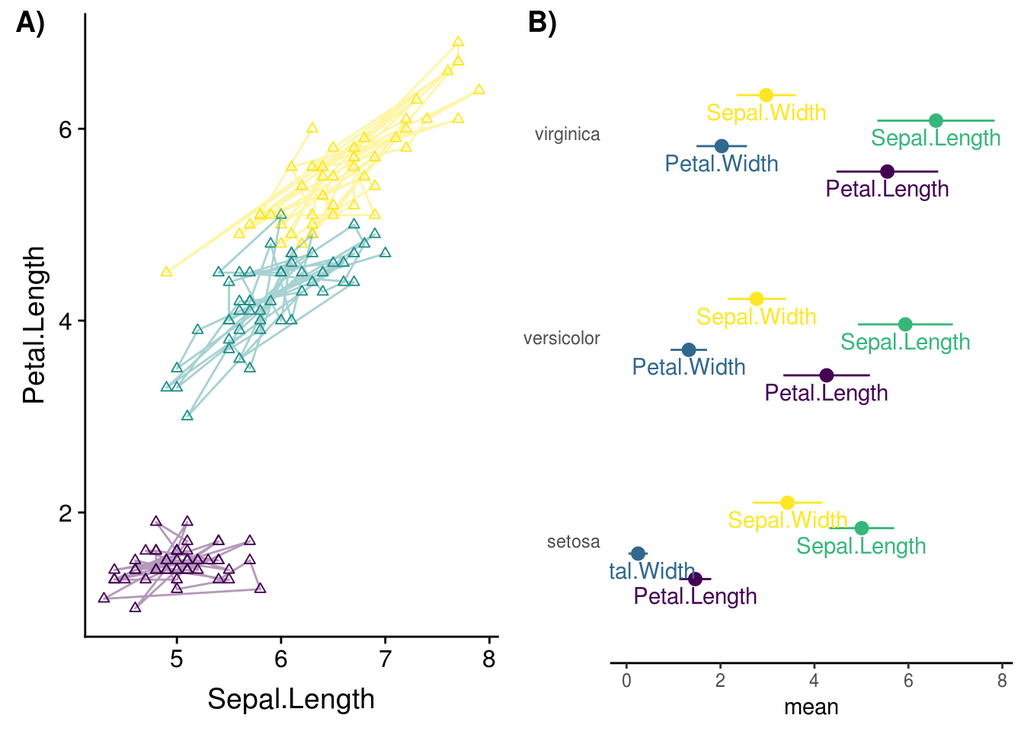

```r
library(cowplot)
p1 <- ggplot(iris, aes(x = Sepal.Length, y = Petal.Length, color = Species)) +
  geom_point(shape = 2) +
  geom_path(alpha = 0.4) +
  scale_color_viridis_d() +
  theme(legend.position = "none")

p2 <- ggplot(iris_sum, aes(x = Species, y = mean, ymin = low, ymax = high,
                     color = key)) +
  geom_pointrange(position = position_dodge(0.5)) +
  geom_text(aes(label = key),
            position = position_dodge(0.5), vjust = 1.5) +
  scale_color_viridis_d() +
  coord_flip() +
  theme(legend.position = "none") +
  theme_classic() +
  theme(
    axis.line.y = element_blank(),
    axis.ticks.y = element_blank()
  ) +
  labs(x = NULL) +
  theme(legend.position = "none")

plot_grid(p1, p2, labels = c("A)", "B)"))
```

## Save/Export plot

`ggplot2` comes with an `ggsave` function, which makes it really easy to save the plots you generated into png, jpg, tiff, pdf, svg, & etc. By default, it will save the last plot but you can choose to save any saved ggplot.

```r
ggsave("myplot.png", width = 9, height = 5, units = "inch", dpi = 300)
```

## Common Figures

### Bar plot with error bar

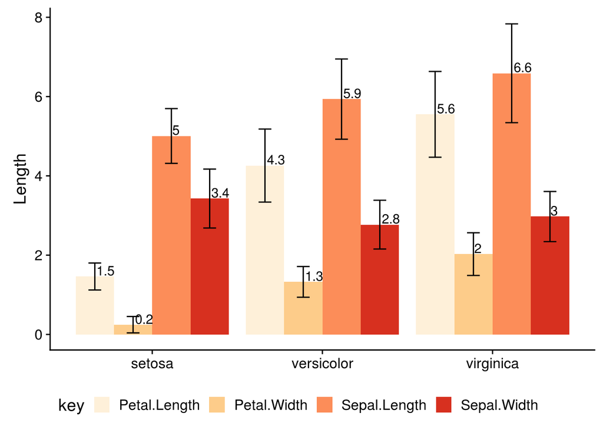

```r
ggplot(iris_sum, aes(x = Species, y = mean)) +
  geom_bar(aes(fill = key), stat = "identity", position = "dodge") +
  geom_errorbar(aes(ymin = low, ymax = high, group = key),
                position = position_dodge(0.9), width = 0.3) +
  geom_text(aes(label = round(mean, 1), group = key),
            position = position_dodge(0.9), vjust = -0.1, hjust = -0.1) +
  scale_fill_brewer(palette="OrRd") +
  labs(x = NULL, y = "Length") +
  theme(legend.position = "bottom")
```

### Forest Plot

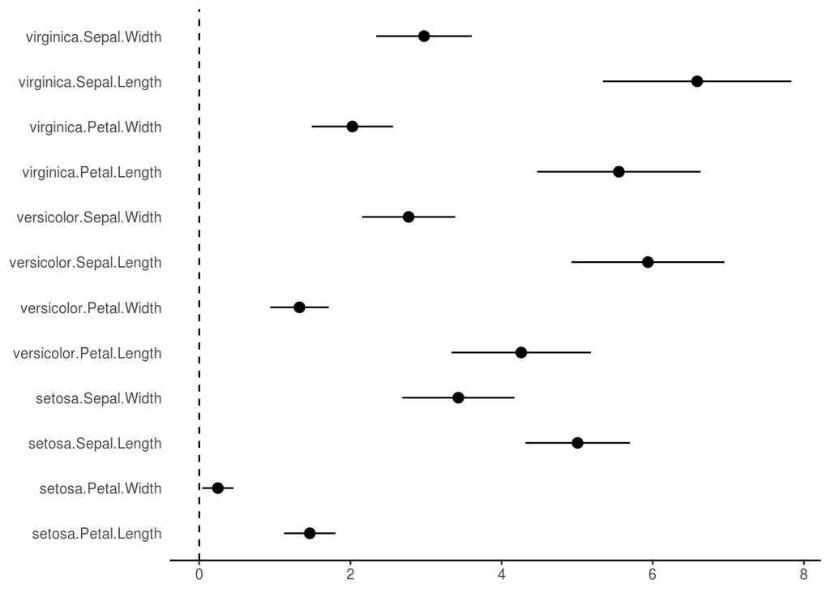

```r
iris_sum2 <- iris_sum %>%
  mutate(name = paste(Species, key, sep = "."))

ggplot(iris_sum2, aes(x = name, y = mean, ymin = low, ymax = high)) +
  geom_pointrange() +
  geom_hline(yintercept = 0, linetype = 2) +
  coord_flip() +
  labs(x = NULL, y = NULL) +
  theme_classic() +
  theme(
    axis.line.y = element_blank(),
    axis.ticks.y = element_blank()
  )
```